# Time Series: A First Course with Bootstrap Starter

# Lesson 7-5: Kolmogorov’s Formula

- We discuss a formula for the one-step ahead prediction MSE.

## Definition 7.5.2.

- For a process $\{ X_t \}$, the **innovation** at time $t$ is the prediction error given the infinite past:
  $$\epsilon_t^{(\infty)} = X_t - P_{ \overline{sp} \{ X_s, s < t \}}
  [X_t].$$
- The one-step ahead prediction error based on the past $n$ observations is
  $$\epsilon_t^{(n)} = X_t - P_{ \overline{sp} \{ X_s, t- n \leq s < t
  \}} [X_t].$$
- It must be true that $\mbox{Var} [\epsilon_t^{(n)}] \geq \mbox{Var} [\epsilon_t^{(\infty)}]$.

## Theorem 7.5.3.

If $\{ X_t \}$ is a causal invertible ARMA with white noise inputs $\{ Z_t \}$ of variance $\sigma^2$, then $Z_t$ is the innovation at time $t$, and as $n \rightarrow \infty$
$$\mbox{Var} [\epsilon_t^{(n)}] \rightarrow \mbox{Var}
[\epsilon_t^{(\infty)}] = \sigma^2.$$

## Example 7.5.4. MA(1) Prediction Variance

- Consider 1-step ahead prediction of an invertible MA(1) process with parameter $\theta$, based on a finite past. Invertibiilty implies $| \theta | <1$.
- From Example 4.6.4,
  $$\mbox{Var} [\epsilon_t^{(n)}] = \gamma (0) -
  \underline{\gamma}^{\prime}_n \,
  \Gamma_n^{-1} \, \underline{\gamma}_n =
  \sigma^2 (1 + \theta^2) - \sigma^2 \theta^2 \frac{1 + \theta^2 + \cdots
  + \theta^{2n-2}}{ 1 + \theta^2 + \cdots + \theta^{2n}}
  = \sigma^2 \frac{1 + \theta^2 + \cdots + \theta^{2n+2}}{ 1 + \theta^2 +
  \cdots + \theta^{2n}},$$
  which is greater than $\sigma^2$ but tends to it (since $|\theta | < 1$) as $n \rightarrow \infty$.

## Exercise 7.42. Prediction Error Variance Computation.

- We numerically demonstrate the formulas of Example 7.5.4, for $2 \leq n \leq 8$.
- Consider $\sigma = 1$ and $\theta = .5$:

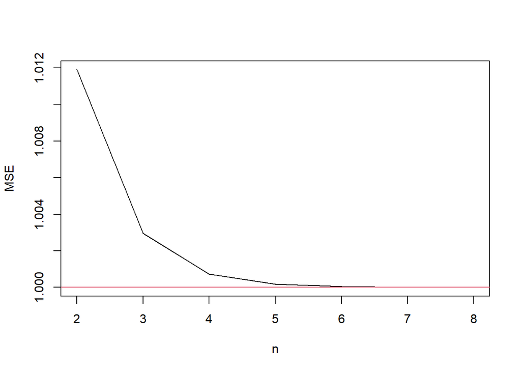

```r
theta <- .5
var.eps <- NULL
for(n in 2:8)
{
    gamma <- c(1+theta^2,theta,rep(0,n-1))
    var.eps <- c(var.eps,gamma[1] - t(gamma[-1]) %*% solve(toeplitz(gamma[-length(gamma)])) %*% gamma[-1])
}
plot(ts(var.eps,start=2),ylab="MSE",xlab="n")
abline(h=1,col=2)
```

- Consider $\sigma = 1$ and $\theta = -.3$:

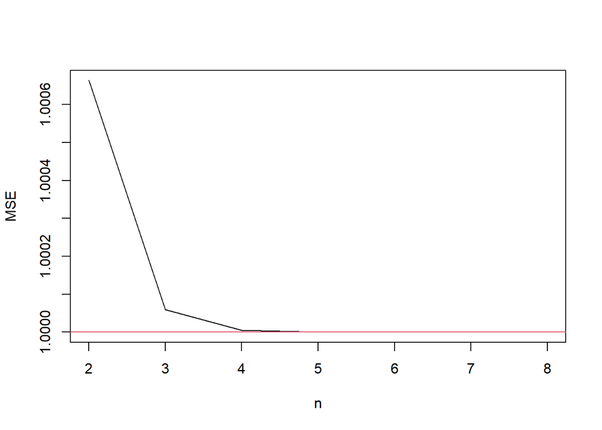

```r
theta <- -.3
var.eps <- NULL
for(n in 2:8)
{
    gamma <- c(1+theta^2,theta,rep(0,n-1))
    var.eps <- c(var.eps,gamma[1] - t(gamma[-1]) %*% solve(toeplitz(gamma[-length(gamma)])) %*% gamma[-1])
}
plot(ts(var.eps,start=2),ylab="MSE",xlab="n")
abline(h=1,col=2)
```

## Theorem 7.5.6. Kolmogorov’s Formula

Let $\{ X_t \}$ be a zero-mean stationary process with absolutely summable ACVF and spectral density $f$ that is positive. Then the innovation variance is
$$\mbox{Var} [\epsilon_t^{(\infty)}] = \exp \left\{ \frac{1}{2 \pi}
\int_{-\pi}^{\pi}
\log f(\lambda) \, d\lambda \right\}.$$

### MA(1) Example

- Consider an MA(1) with $\theta = .5$ and $\sigma = 1$. We numerically compute Kolmogorov’s formula, and should obtain 1 (as a verification).

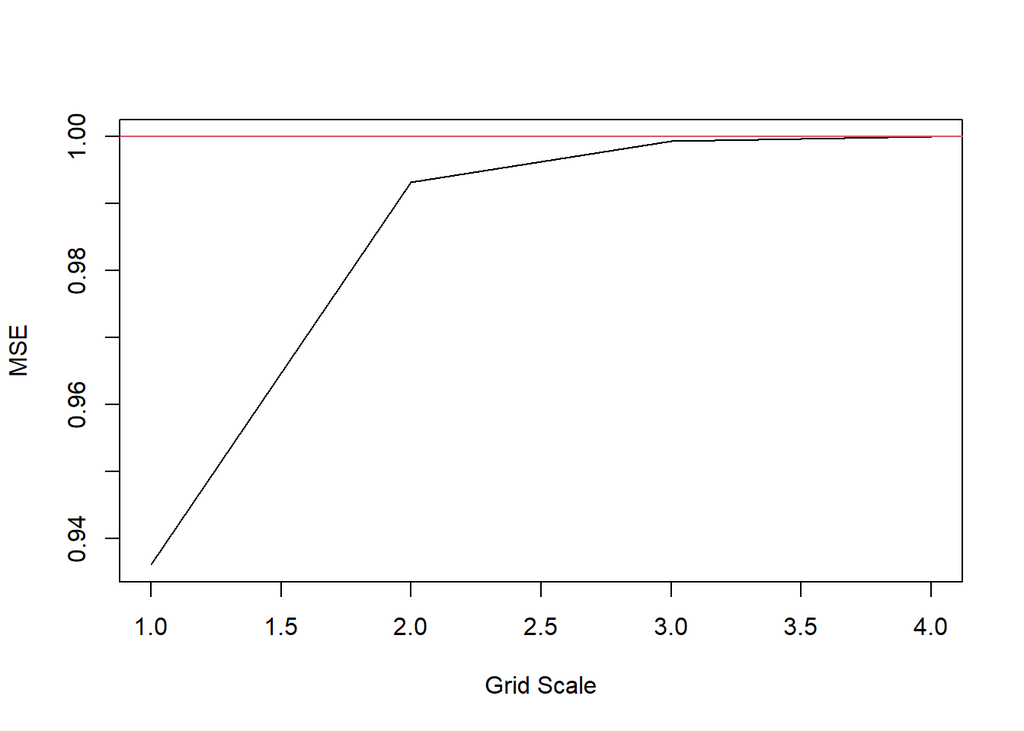

```r
theta <- .5
kolg <- NULL
grids <- 10^seq(1,4)
for(grid in grids)
{
  lambda <- pi*seq(-grid,grid)/grid
  spec.ma <- Mod(1 + theta*exp(-1i*lambda))^2
  kolg <- c(kolg,exp(mean(log(spec.ma))))
}
plot(ts(kolg,start=1),ylab="MSE",xlab="Grid Scale")
abline(h=1,col=2)
```